# Fundamentals of asking questions

MACS 30000 University of Chicago

October 16, 2017

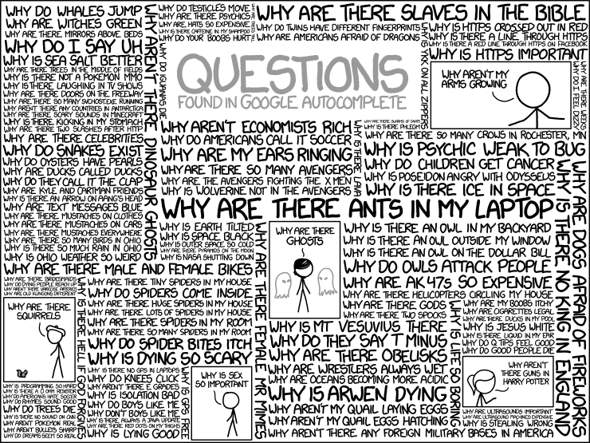

## Total survey error

- Census
- Sample
- Sources of error
  - Representation errors
  - Measurement errors

## Representation errors

- When the survey does not accurately represent the population of interest
- *Literary Digest* poll
  - Target population
  - Frame population
- Non-response bias
  - Sample population
  - Respondents
  - Factors
  - How to fix

## Measurement errors

- > If you could choose between the following two approaches, which do you think is the better penalty for murder - the death penalty or life imprisonment, with absolutely no possibility of parole?
- > Are you in favor of the death penalty for a person convicted of murder?

## Measurement errors

- How we make inferences from the answers that respondents give to our questions
- [TIL that only 34% of American Millenials think that “America is the greatest country in the world” while that number is at almost 70% for Baby Boomers.](https://np.reddit.com/r/todayilearned/comments/590tip/til_that_only_34_of_american_millenials_think/)
- When measurement error is interesting

## Probability sampling

- Simple random sampling
- Adjusting estimates
- Oversampling and undersampling
- Post-stratification and weighting

## U.S. presidential election polls

- Four reputable pollsters, given the same raw data, arrived at different conclusions about who led the presidential race in Florida
- Cannot be sampling error
- What are the potential sources of error that account for these differences?
- Which approach would you use to weight the survey results?

## Non-probability samples

- Homogenous-response-propensities-within-group assumption
- Response-propensity assumption
- When are these assumptions true
- Data sparsity

## Multilevel regression and post-stratification (MRP)

1. Collect your sample (probability or non-probability)
2. Divide the sample into many groups based on known characteristics
3. Estimate a multilevel regression model
4. Average over each group (cell) to calculate the estimate of interest
5. Post-stratify the results based on each group’s prevalence in the known population

## Failure of US presidential election polls (2016)

- [Whoopsie](https://projects.fivethirtyeight.com/2016-election-forecast/national-polls/)
- Assessment under total survey error framework
  - Representation error
  - Measurement error